# PPOL 628 Final Project

Dain Yoo

12/14/2020

- [Github Repo](https://github.com/dainyoo46/final_project)
- [Github Page](https://dainyoo46.github.io/final_project/)

### Research puzzle

I am interested in how Egyptian public opinion shifts after the adoption of anti-terror law in Egypt. Specifically, I am interested in exploring polarization between secularists and Islamists as anti-terror law, by nature, targets Islamist extremists and the secular regime would target the Islamists as potential threat to national security.

### Why Egypt?

The Middle East and North Africa is a particularly interesting region in a way that only few anti-terror laws have been passed by the states despite experiencing the highest level of global terrorism. In fact, we can see from Figure 2, which is a normalized graph of the number of anti- terror laws passed per 100 terrorist attacks, that it is not only one of the few regions that did not see a surge in anti-terror law adoption after the 9/11, marked in a blue vertical line at year 2001, but also shows no significant performance in legal enactment in general despite the high level of terrorist attacks.

This region is also an interesting place to look at the effect of anti-terror laws since the Islamist groups have always been either marginalized, repressed or coopted by the secularist dictatorships and monarchs. Egypt is one of the countries where political Islamist groups have been marginalized by the nationalist secular authorities since the 1960s. In fact, the Muslim Brotherhood has been outlawed in 2013 and criticized as a terrorist organization, but still a third of Egyptians support the Muslim Brotherhood, implying that there would be some kind of polarization among its population.

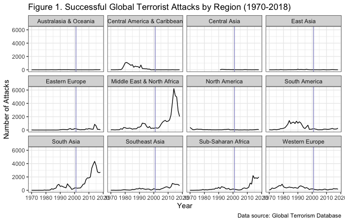

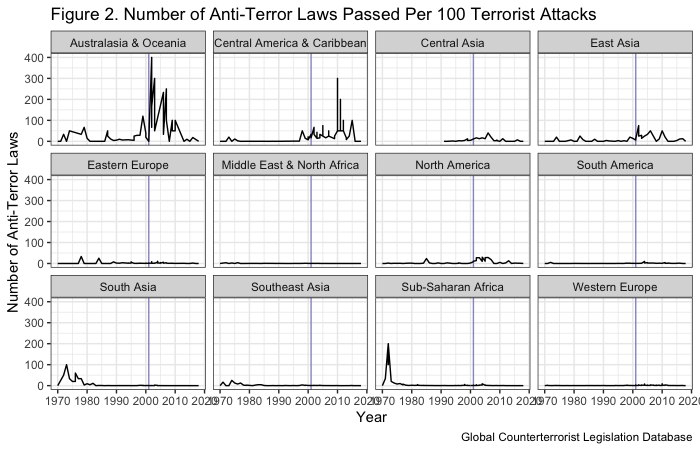

### Data and Methods

I use Arab Barometer survey data (2006-2019) to observe latent clusters within public opinion. Because Egypt adopted anti-terror in 2015, I use Wave 3 (2012-2014) and Wave 4 (2016-2017) to see how polarization exacerbated in Egypt after the enactment.

Among various questionnaires, I included 20 of them for more variation across clusters. They include binary variables (e.g. urban/rural, male/female, voted/did not vote), categorical ordinal variable (e.g. not at all/once a month/once a week/daily, level of education) and continuous variable (e.g. age). Topics of the selected questionnaires include political participation, religious practices, media exposure and stances on economic and diplomatic issues.

### Preprocessing - Survey weight

To preprocess the data before analyzing, I account for the weight of the survey to get an ideal representation of the population. As for the first dataset (2012-2014), the weights range from 0.047 to 6.07 while that of the second dataset (2016-2017) range from 0.67 to 1.90. To keep the number of observations similar, I multiply the weights by 10 and round to a whole number. Then I duplicate the each observation by the rounded weight.

```r
# Account for weights
summary(egypt1$wt)
```

```
##    Min. 1st Qu.  Median    Mean 3rd Qu.    Max.
## 0.04682 0.30160 0.55755 0.99890 1.49489 6.06972
```

```r
summary(egypt2$wt)
```

```
##    Min. 1st Qu.  Median    Mean 3rd Qu.    Max.
##  0.6708  0.6708  0.9796  1.0000  1.1782  1.8947
```

```r
# Duplicated observations by weight*10
# and rounded to a whole number
wt1 <- egypt1 %>%
  mutate(wt10 = wt*10, wt_round = round(wt10, 0))
wt2 <- egypt2 %>%
  mutate(wt10 = wt*10, wt_round = round(wt10, 0))

egypt_wt1 <- wt1 %>%
  uncount(wt_round)
egypt_wt2 <- wt2 %>%
  uncount(wt_round)
```

### Normalize responses

In this section, I normalize the responses to convert them uniformly into a numeric vector that ranges from 0 to 1. For binary variables, I recode them into 0 or 1 and, as for the continuous variable (age), I divide the values by 61 as the oldest respondent in each period is 61 and 58 respectively. I rescale them ordinal categorical variables, I use scaling method, by replacing each ordinal categorical variable with the equation below:
$$\frac{i-1/2}{M}$$

I reiterate this for Wave 4 as well. One thing to note is that there are questions that appear in Wave 3 but not in Wave 4. One important question is q20112 which asks respondents how much trust they have for the Muslim Brotherhood, which is an ideal indicator to measure public opinion on the organization that is outlawed by the government and is often framed as terrorist organization by the government. In this analysis I include this question for Wave 3 due to its significance, but instead in Wave 4, I add question q1072 (which again does not appear in Wave 3) on how much individuals are worried about terrorism.

```r
# Recode responses (wave 3)
egypt_1 <- egypt_wt1 %>%
  mutate(q1001 = as.numeric(q1001),
         q1001 = q1001/61) %>%
  mutate(q13 = recode(q13,
                        "Rural" = 0,
                        "Urban" = 1)) %>%
  mutate(q1002 = recode(q1002,
                        "Female" = 0,
                        "Male" = 1)) %>%
  mutate(q1012 = recode(q1012,
                        "Christian" = 0,
                        "Muslim" = 1)) %>%
  mutate(q1004 = recode(q1004,
                        "No" = 0,
                        "Yes" = 1)) %>%
    filter(!q301 %in% c("Refuse",
                        "Don't know")) %>%
    mutate(q301 = recode(q301,
                        "No" = 0,
                        "Yes" = 1)) %>%
    filter(!q210 %in% c("Don't know")) %>%
    mutate(q210 = recode(q210,
                        "No" = 0,
                        "Yes" = 1)) %>%
    mutate(q1003 = recode(q1003,
                          "Illiterate/No formal education" = 0.07,
                          "Elementary" = 0.21,
                          "Prepartory/Basic" = 0.36,
                          "Secondary" = 0.5,
                          "Mid-level diploma (professional or technical" = 0.64,
                          "ba" = 0.79,
                          "MA and above" = 0.96)) %>%
  filter(!q6101 %in% c("Refuse",
                        "Don't know")) %>%
  mutate(q6101 = recode(q6101,
                        "Never" = 0.1,
                        "Rarely" = 0.3,
                        "Sometimes" = 0.5,
                        "Most of the time" = 0.7,
                        "Always"= 0.9)) %>%
  filter(!q6105 %in% c("Refuse",
                        "Don't know")) %>%
  mutate(q6105 = recode(q6105,
                        "Never" = 0.1,
                        "Rarely" = 0.3,
                        "Sometimes" = 0.5,
                        "Most of the time" = 0.7,
                        "Always"= 0.9)) %>%
  filter(!q609 %in% c("Refuse")) %>%
  mutate(q609 = recode(q609,
                        "Not religious" = 0.17,
                        "Somewhat religious" = 0.5,
                        "Religious" = 0.83)) %>%
  filter(!q605a %in% c("Don't know")) %>%
  mutate(q605a = recode(q605a,
                        "I Strongly agree with the 1st sentence" = 0.1,
                        "I agree with the 1st sentence" = 0.3,
                        "I do not agree with either sentence (Do not read)" = 0.5,
                        "I agree with the 2nd sentence" = 0.7,
                        "I strongly agree with the 2nd sentence"= 0.9)) %>%
  filter(!q523 %in% c("Don't know")) %>%
  mutate(q523 = recode(q523,
                        "Not justified at all" = 0.125,
                        "Justified to a limited extent" = 0.375,
                        "Justified to a medium extent" = 0.625,
                        "Justified to a great extent" = 0.875)) %>%
  filter(!q513 %in% c("Don't know",
                      "Refuse",
                      "Not concerned / Not interested")) %>%
  mutate(q513 = recode(q513,
                       "1" = 1,
                       "2" = 2,
                       "3" = 3,
                       "4" = 4,
                       "5" = 5,
                       "6" = 6,
                       "7" = 7,
                       "8" = 8,
                       "9" = 9,
                        "Absolutely unsatisfied" = 0.1,
                        "Completely satisfied" = 10),
         q513 = q513/10) %>%
  filter(!q409 %in% c("Don't know")) %>%
  mutate(q409 = recode(q409,
                         "Daily or almost daily" = 0.9 ,
                         "At least once a week" = 0.7,
                         "At least once a month" = 0.5,
                         "A few times a year" = 0.3,
                         "I do not use the internet" = 0.1)) %>%
  filter(!q404 %in% c("Don't know")) %>%
  mutate(q404 = recode(q404,
                         "Not interested" = 0.125,
                         "Slightly interested" = 0.375,
                         "Interested" = 0.625,
                         "Very interested" = 0.875)) %>%
  filter(!q301 %in% c("Refuse",
                      "Don't know")) %>%
  filter(!q210 %in% c("Don't know")) %>%
  filter(!q20112 %in% c("Refuse",
                        "Don't know")) %>%
  mutate(q20112 = recode(q20112,
                         "I absolutely do not trust it" = 0.125,
                         "I trust it to a limited extent" = 0.375,
                         "I trust it to a medium extent" = 0.625,
                         "I trust it to a great extent" = 0.875)) %>%
  filter(!q106 %in% c("Refuse",
                      "Don't know")) %>%
  mutate(q106 = recode(q106,
                         "Not at all" = 0.125,
                         "To a limited extent" = 0.375,
                         "To a medium extent" = 0.625,
                         "To a great extent" = 0.875)) %>%
  filter(!q105 %in% c("Refuse",
                      "Don't know")) %>%
  mutate(q105 = recode(q105,
                         "Absolutely not ensured" = 0.125,
                         "Not ensured" = 0.375,
                         "Ensured" = 0.625,
                         "Fully ensured" = 0.875)) %>%
  filter(!q102 %in% c("Refuse",
                      "Don't know")) %>%
  mutate(q102 = recode(q102,
                         "Much worse" = 0.1,
                         "Somewhat worse" = 0.3,
                         "Almost the same as the current situation" = 0.5,
                         "Somewhat better" = 0.7,
                         "Much better" = 0.9))
```

### Number of clusters

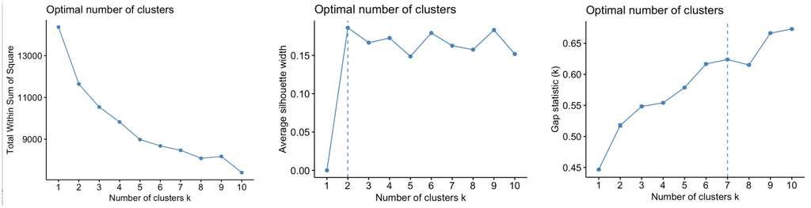

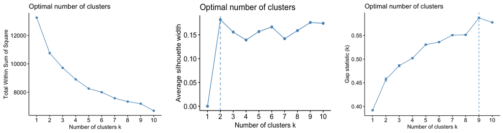

```r
#Clustering Analysis
set.seed(2020)
egypt1_kmeans <- kmeans(na.omit(egypt_1),
                       centers = 9, # number of clusters
                       nstart = 100)
egypt2_kmeans <- kmeans(na.omit(egypt_2),
                       centers = 9, # number of clusters
                       nstart = 100)
```

### Prediction

```r
# Expert check
mean1 <- bind_cols(
  egypt_1,
  cluster = egypt1_kmeans$cluster) %>%
  group_by(cluster) %>%
  summarise(across(everything(), list(mean)))
mean2 <- bind_cols(
  egypt_2,
  cluster = egypt2_kmeans$cluster) %>%
  group_by(cluster) %>%
  summarise(across(everything(), list(mean)))
mean1 %>% knitr::kable(digits = 2)
```

| cluster | q13_1 | q1002_1 | q1012_1 | q1004_1 | q1001_1 | q1003_1 | q102_1 | q105_1 | q106_1 | q20112_1 | q210_1 | q301_1 | q404_1 | q409_1 | q513_1 | q523_1 | q605a_1 | q609_1 | q6105_1 | q6101_1 |
| --- | --- | --- | --- | --- | --- | --- | --- | --- | --- | --- | --- | --- | --- | --- | --- | --- | --- | --- | --- | --- |
| 1 | 0.00 | 0.00 | 1.00 | 0.17 | 0.52 | 0.33 | 0.35 | 0.33 | 0.46 | 0.27 | 0.97 | 0.00 | 0.33 | 0.26 | 0.32 | 0.29 | 0.45 | 0.69 | 0.61 | 0.86 |
| 2 | 0.00 | 0.98 | 0.98 | 0.70 | 0.41 | 0.46 | 0.46 | 0.39 | 0.40 | 0.34 | 1.00 | 0.00 | 0.34 | 0.26 | 0.30 | 0.23 | 0.50 | 0.54 | 0.83 | 0.77 |
| 3 | 1.00 | 0.00 | 0.99 | 0.12 | 0.63 | 0.38 | 0.37 | 0.28 | 0.38 | 0.22 | 0.97 | 0.71 | 0.48 | 0.26 | 0.18 | 0.28 | 0.50 | 0.64 | 0.72 | 0.84 |
| 4 | 0.00 | 0.96 | 0.98 | 1.00 | 0.61 | 0.34 | 0.28 | 0.35 | 0.40 | 0.18 | 0.92 | 1.00 | 0.56 | 0.30 | 0.17 | 0.33 | 0.44 | 0.66 | 0.87 | 0.80 |
| 5 | 0.05 | 1.00 | 1.00 | 0.00 | 0.82 | 0.35 | 0.39 | 0.33 | 0.42 | 0.20 | 0.90 | 1.00 | 0.57 | 0.23 | 0.28 | 0.61 | 0.33 | 0.76 | 0.90 | 0.88 |
| 6 | 0.08 | 0.73 | 0.97 | 0.97 | 0.60 | 0.44 | 0.67 | 0.44 | 0.61 | 0.67 | 0.93 | 1.00 | 0.60 | 0.46 | 0.61 | 0.51 | 0.26 | 0.65 | 0.85 | 0.84 |
| 7 | 1.00 | 0.85 | 0.98 | 0.69 | 0.54 | 0.40 | 0.31 | 0.27 | 0.39 | 0.19 | 0.98 | 0.00 | 0.45 | 0.33 | 0.20 | 0.36 | 0.58 | 0.61 | 0.82 | 0.76 |
| 8 | 0.00 | 0.00 | 0.98 | 0.00 | 0.58 | 0.33 | 0.37 | 0.33 | 0.46 | 0.30 | 0.94 | 1.00 | 0.48 | 0.22 | 0.28 | 0.42 | 0.38 | 0.70 | 0.75 | 0.86 |
| 9 | 1.00 | 0.98 | 0.96 | 0.75 | 0.61 | 0.47 | 0.34 | 0.35 | 0.43 | 0.20 | 1.00 | 1.00 | 0.56 | 0.44 | 0.18 | 0.24 | 0.62 | 0.56 | 0.85 | 0.77 |

```r
mean2 %>% knitr::kable(digits = 2)
```

| cluster | q13_1 | q1002_1 | q1012_1 | q1004_1 | q1001_1 | q1003_1 | q102_1 | q105_1 | q106_1 | q1072_1 | q210_1 | q301_1 | q404_1 | q409_1 | q513_1 | q523_1 | q605a_1 | q609_1 | q6106_1 | q6101_1 |
| --- | --- | --- | --- | --- | --- | --- | --- | --- | --- | --- | --- | --- | --- | --- | --- | --- | --- | --- | --- | --- |
| 1 | 1 | 0.00 | 0.99 | 0.01 | 0.69 | 0.36 | 0.62 | 0.62 | 0.45 | 0.83 | 0.77 | 1.00 | 0.43 | 0.23 | 0.51 | 0.39 | 0.50 | 0.63 | 0.76 | 0.75 |
| 2 | 0 | 0.00 | 0.96 | 0.11 | 0.56 | 0.41 | 0.58 | 0.61 | 0.44 | 0.81 | 0.73 | 1.00 | 0.37 | 0.26 | 0.52 | 0.36 | 0.42 | 0.62 | 0.71 | 0.77 |
| 3 | 1 | 1.00 | 0.94 | 0.00 | 0.55 | 0.47 | 0.59 | 0.61 | 0.49 | 0.76 | 0.72 | 0.52 | 0.41 | 0.57 | 0.51 | 0.38 | 0.53 | 0.56 | 0.70 | 0.70 |
| 4 | 1 | 0.00 | 0.99 | 0.00 | 0.58 | 0.43 | 0.54 | 0.56 | 0.41 | 0.83 | 0.70 | 0.00 | 0.36 | 0.32 | 0.41 | 0.34 | 0.50 | 0.62 | 0.74 | 0.75 |
| 5 | 1 | 0.86 | 0.88 | 1.00 | 0.71 | 0.55 | 0.63 | 0.66 | 0.48 | 0.80 | 0.70 | 1.00 | 0.45 | 0.41 | 0.50 | 0.38 | 0.51 | 0.58 | 0.69 | 0.75 |
| 6 | 0 | 0.19 | 0.95 | 0.00 | 0.48 | 0.43 | 0.56 | 0.63 | 0.49 | 0.81 | 0.66 | 0.00 | 0.27 | 0.31 | 0.48 | 0.33 | 0.38 | 0.61 | 0.74 | 0.75 |
| 7 | 0 | 0.99 | 0.90 | 0.73 | 0.73 | 0.43 | 0.65 | 0.68 | 0.54 | 0.77 | 0.68 | 1.00 | 0.48 | 0.25 | 0.58 | 0.37 | 0.48 | 0.61 | 0.74 | 0.81 |
| 8 | 0 | 0.82 | 0.98 | 1.00 | 0.56 | 0.53 | 0.48 | 0.62 | 0.35 | 0.80 | 0.76 | 0.00 | 0.34 | 0.39 | 0.35 | 0.27 | 0.46 | 0.62 | 0.74 | 0.80 |
| 9 | 1 | 0.73 | 1.00 | 1.00 | 0.54 | 0.52 | 0.55 | 0.56 | 0.39 | 0.80 | 0.80 | 0.00 | 0.42 | 0.47 | 0.38 | 0.30 | 0.52 | 0.57 | 0.69 | 0.75 |

### PCA - Visualization

Since PCA1 and PCA2 only explain 38% of the data, the vizualization would not be as useful.

```r
#PCA
principle_components1 <- prcomp(egypt_1, scale. = FALSE)
principle_components2 <- prcomp(egypt_2, scale. = FALSE)

# view the amount of variance explained
summary(principle_components1)
```

```
## Importance of components:
##                           PC1    PC2    PC3     PC4    PC5     PC6     PC7
## Standard deviation     0.6447 0.5274 0.4353 0.41213 0.3452 0.33260 0.29025
## Proportion of Variance 0.2327 0.1557 0.1061 0.09507 0.0667 0.06192 0.04716
## Cumulative Proportion  0.2327 0.3884 0.4945 0.58953 0.6562 0.71816 0.76531
##                            PC8     PC9    PC10    PC11    PC12    PC13    PC14
## Standard deviation     0.24239 0.22269 0.21156 0.20725 0.19288 0.18401 0.17304
## Proportion of Variance 0.03289 0.02776 0.02505 0.02404 0.02082 0.01895 0.01676
## Cumulative Proportion  0.79820 0.82596 0.85101 0.87505 0.89588 0.91483 0.93159
##                          PC15   PC16    PC17    PC18    PC19    PC20
## Standard deviation     0.1615 0.1581 0.15085 0.13963 0.13316 0.10548
## Proportion of Variance 0.0146 0.0140 0.01274 0.01091 0.00993 0.00623
## Cumulative Proportion  0.9462 0.9602 0.97293 0.98385 0.99377 1.00000
```

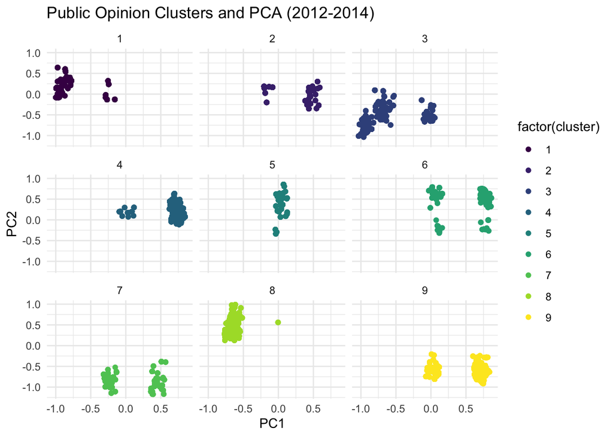

```r
# create and visualize the group membership of observations in the components
bind_cols(
  as_tibble(principle_components1$x),
  cluster = egypt1_kmeans$cluster) %>%
  ggplot(aes(PC1, PC2, color = factor(cluster))) + geom_point() +
  scale_color_viridis_d() + facet_wrap(~ cluster) +
  labs(title = "Public Opinion Clusters and PCA (2012-2014)") + theme_minimal()
```

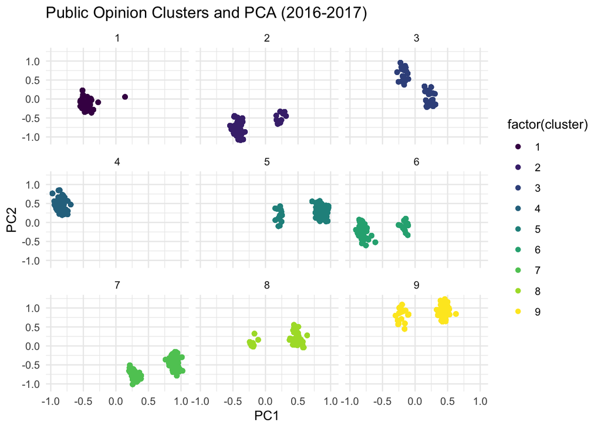

```r
bind_cols(
  as_tibble(principle_components2$x),
  cluster = egypt2_kmeans$cluster) %>%
  ggplot(aes(PC1, PC2, color = factor(cluster))) + geom_point() +
  scale_color_viridis_d() + facet_wrap(~ cluster) +
  labs(title = "Public Opinion Clusters and PCA (2016-2017)") + theme_minimal()
```

### Parellel coordinates plot

As an alternative, I plot a parellel coordinates plot which shows how each clusters are posited within or consisted of each variables, or, in this case, questionnaires. The figure below shows how the nine clusters contain information of the questionnaires. There is clearly differences across variables in terms of variance across clusters. For instance, the first few variables that are binary (e.g. gender, urban/rural) have higher variance than questions asking if they are concerned about terrorism (T2, q1072) or religiosity (T1, q609).

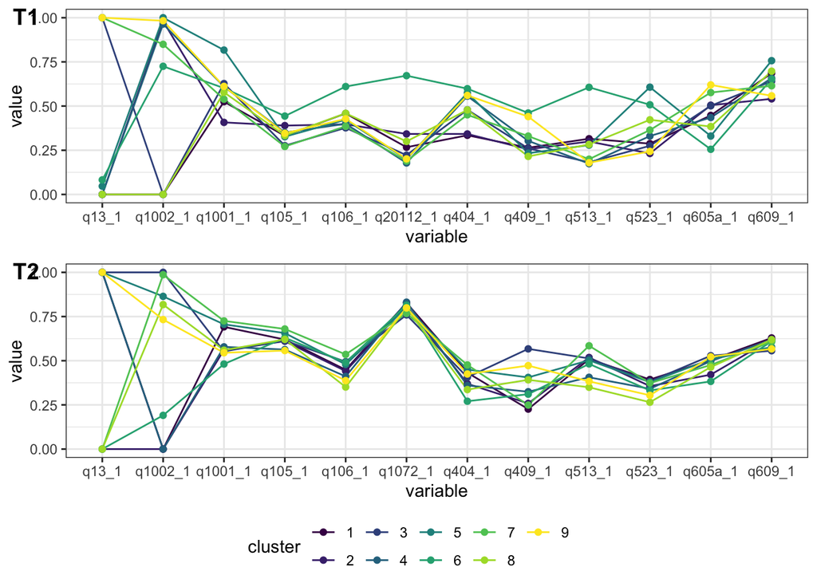

```r
#Parellel coordinate plot
x <- ggparcoord(mean1, columns = c(2:3,6,9:11,14:19),
                groupColumn = 'cluster', scale = 'globalminmax',
                showPoints = TRUE) + theme_bw() + scale_color_viridis(discrete=TRUE)

y <- ggparcoord(mean2, columns = c(2:3,6,9:11,14:19),
                groupColumn = 'cluster', scale = 'globalminmax',
                showPoints = TRUE) + theme_bw() + scale_color_viridis(discrete=TRUE)

ggarrange(
  x, y, labels = c("T1", "T2"),
  common.legend = TRUE, legend = "bottom", nrow = 2
  )
```

The variable that I make a foundational reference is q605a, which is their response on political parties - secular vs. religious politial party. These are clusters of people who either responded they prefer Islamist political parties or secular political parties.

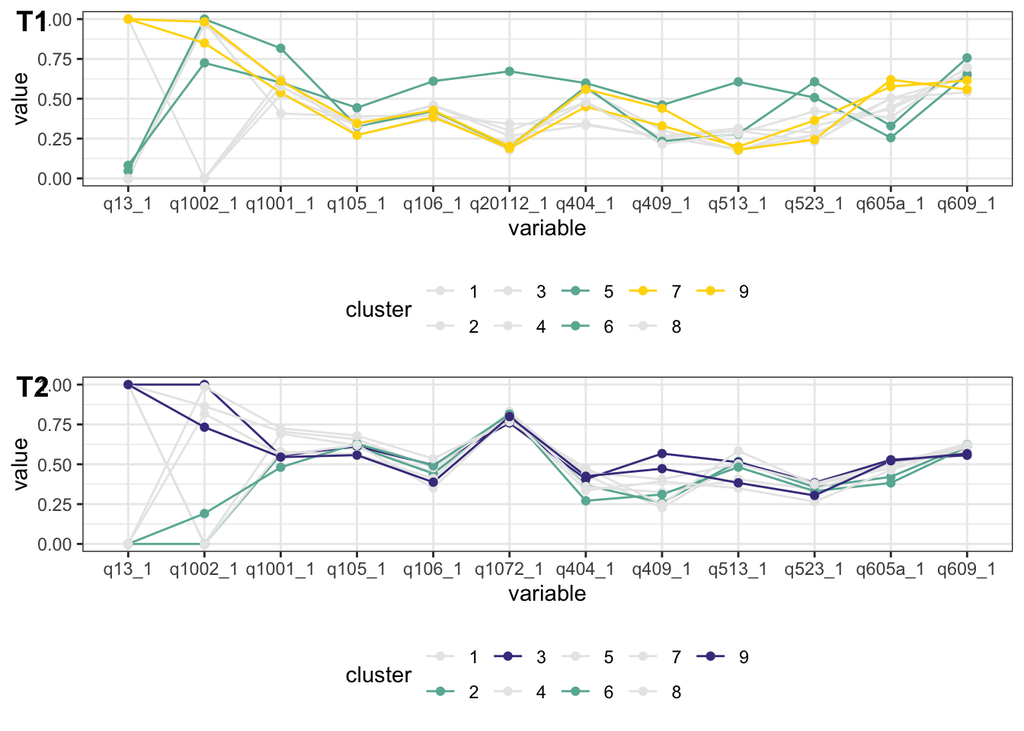

```r
## Highlight
filter1 <- mean1 %>%
  group_by(cluster) %>%
  filter(cluster == 6) %>%
  ungroup()

a <- mean1 %>%
  ggparcoord(columns = c(2:3,6,9:11,14:19),
             groupColumn = 'cluster', scale = 'globalminmax',
             showPoints = TRUE) + theme_bw() +
  scale_color_manual(values=c("#E8E8E8", "#E8E8E8", "#E8E8E8", "#E8E8E8", "#69b3a2",
                              "#69b3a2", "gold1", "#E8E8E8", "gold1"))

b <- mean2 %>%
  ggparcoord(columns = c(2:3,6,9:11,14:19),
             groupColumn = 'cluster', scale = 'globalminmax',
             showPoints = TRUE) + theme_bw() +
  scale_color_manual(values=c("#E8E8E8", "#69b3a2", "slateblue4", "#E8E8E8", "#E8E8E8",
                              "#69b3a2", "#E8E8E8", "#E8E8E8", "slateblue4"))
#Plot
ggarrange(
  a, b, labels = c("T1", "T2"),
  common.legend = FALSE, legend = "bottom", nrow = 2
  )
```

## Political Polarization

From the summary below, we see the size (percentage) of each clusters. Before anti-terror law was adopted in Egypt, those who prefer Islamist political parties (cluster 5 and 6) account for 14.9% of the entire repondents while those who prefer secular political parties (cluster 7 and 9) account for 21.3%.

In the post-treatment period or after the anti-terror law enactment, the overall trend shift slightly to the pro-Islamist stance. While those who prefer Islamist political parties (cluster 2 and 6) account for 25.5% of the entire repondents, those who prefer secular political parties (cluster 3 and 9) account for 16.9%.

While there are more pro-Islamist groups within the survey respondents after the anti-terror law adoption, it is hard to conclude that pro-secular groups have changed their political stance or ideology. It could be due to the growing distrust and disappointment of the general public towards the government and the incumbent political party, which is prevalent in Arab region as a whole.

```
## # A tibble: 9 x 3
##   cluster     n  freq
##     <int> <int> <dbl>
## 1       1   739  9.32
## 2       2   412  5.20
## 3       3  1185 14.9
## 4       4  1505 19.0
## 5       5   429  5.41
## 6       6   753  9.50
## 7       7   578  7.29
## 8       8  1214 15.3
## 9       9  1114 14.0
```

```
## # A tibble: 9 x 3
##   cluster     n  freq
##     <int> <int> <dbl>
## 1       1   471  6.65
## 2       2   874 12.3
## 3       3   508  7.17
## 4       4   937 13.2
## 5       5   876 12.4
## 6       6   933 13.2
## 7       7  1268 17.9
## 8       8   521  7.35
## 9       9   696  9.82
```